# **Import the libraries, load dataset, print shape of data, visualize the images in dataset. (5 Marks)**

```python
# Import the libraries, load dataset, print shape of data, visualize the images in dataset. (5 Marks)

import pandas as pd
import numpy as np
import tensorflow as tf
import matplotlib.pyplot as plt
import seaborn as sns
from tensorflow import keras
from tensorflow.keras.preprocessing.image import ImageDataGenerator
from tensorflow.keras.models import Sequential
from tensorflow.keras.layers import Dense, Dropout, Activation, Flatten
from tensorflow.keras.layers import Conv2D, MaxPooling2D
from tensorflow.keras.utils import to_categorical
from sklearn.preprocessing import normalize
from sklearn.model_selection import train_test_split
import matplotlib.pyplot as plt
%matplotlib inline
import cv2
from google.colab.patches import cv2_imshow
from google.colab import drive
```

```python
drive.mount('/content/drive')
%cd /content/drive/'My Drive'/project7
```

```
/content/drive/My Drive/project7
```

```python
# The image array is saved in the file images.npy  Load the image Data
X = np.load('images.npy')
```

```python
#The labels are stored in Lables.csv file. Read them from the file. Load the lable data
y = pd.read_csv("Labels.csv");
```

```python
#Print the shape of the image data
print(X.shape)
```

```
(4750, 128, 128, 3)
```

```python
X.astype('float32')
```

[output not shown]

[output cut: 252 more lines]

[output not shown]

- The training set contains 4750 images.
- The size of each image is 128x128 pixels.
- Each image has 3 color channels.

```python
#Print the shape of the label data
y.shape
```

```
(4750, 1)
```

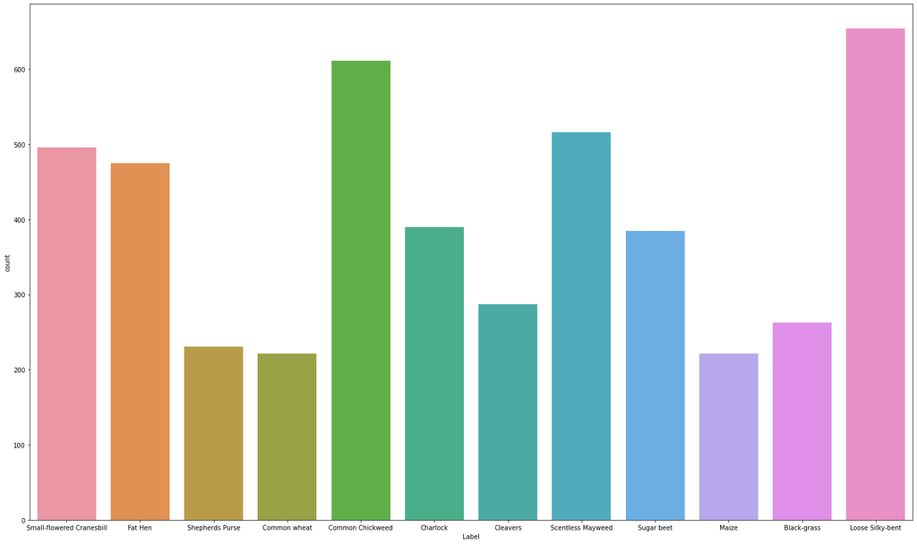

```python
plt.figure(figsize=(25,15))
sns.countplot(y["Label"])
```

```
 Seedling Name: Small-flowered Cranesbill
```

```python
#Visualize images in the data set (The first sample is:  Small-Flowered Cranesbill)
i = 0
image = X[i]
label = y['Label'][i]
print(' Seedling Name: ' + label +"\n")
cv2_imshow(image)
```

[output not shown]

```
 Seedling Name: Fat Hen
```

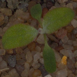

```python
i = 903
image = X[i]
label = y['Label'][i]
print(' Seedling Name: ' + label +"\n")
cv2_imshow(image)
```

```
 Seedling Name: Shepherds Purse
```

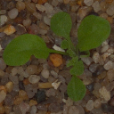

```python
i = 1004
image = X[i]
label = y['Label'][i]
print(' Seedling Name: ' + label +"\n")
cv2_imshow(image)
```

# **Data Pre-processing: (15 Marks)**

> a. Normalization.

> b. Gaussian Blurring.

> c. Visualize data after pre-processing.

### Normalize data

- we must normalize our data as it is always required in neural network models

```python
# Normalize the data
X_Preprocessed = X.copy()
for idx, line in enumerate(X_Preprocessed):
  X_Preprocessed[idx] = cv2.normalize(line, None, 0, 255, norm_type=cv2.NORM_MINMAX, dtype=cv2.CV_8UC3)
```

```
 Seedling Name: Small-flowered Cranesbill
```

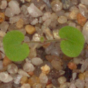

```python
#Visualize images in the data set after pre-processing "Normalized" (The first sample is:  Small-Flowered Cranesbill)
i = 0
image =X_Preprocessed[i]
label = y['Label'][i]
print(' Seedling Name: ' + label +"\n")
cv2_imshow(image)
```

```
 Seedling Name: Fat Hen
```

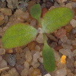

```python
i = 903
image = X_Preprocessed[i]
label = y['Label'][i]
print(' Seedling Name: ' + label +"\n")
cv2_imshow(image)
```

```
 Seedling Name: Shepherds Purse
```

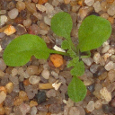

```python
i = 1004
image = X_Preprocessed[i]
label = y['Label'][i]
print(' Seedling Name: ' + label +"\n")
cv2_imshow(image)
```

### Gaussian Blurring

- **Gaussian Blurring:** Gaussian blur is the result of blurring an image by a Gaussian function.
- It is a widely used effect in graphics software, typically to **reduce image noise** and **reduce detail**. It is also used as a **preprocessing** stage before applying our machine learning or deep learning models.
- We should specify the *width* and *height* of the **kernel** which should be **positive and odd**. We also should specify the standard deviation in the X and Y directions, sigmaX and sigmaY respectively. If only sigmaX is specified, sigmaY is taken as equal to sigmaX.

```python
# Now we apply the gaussian blur to each 128x128 pixels array (image) to reduce the noise in the image
for idx, line in enumerate(X_Preprocessed):
  X_Preprocessed[idx] = cv2.GaussianBlur(line, (5, 5), 0)
```

```
 Seedling Name: Small-flowered Cranesbill
```

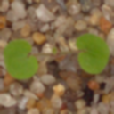

```python
#Visualize images in the data set after pre-processing "Gaussian Blur" (The first sample is:  Small-Flowered Cranesbill)
i = 0
image =X_Preprocessed[i]
label = y['Label'][i]
print(' Seedling Name: ' + label +"\n")
cv2_imshow(image)
```

```
 Seedling Name: Fat Hen
```

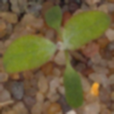

```python
i = 903
image = X_Preprocessed[i]
label = y['Label'][i]
print(' Seedling Name: ' + label +"\n")
cv2_imshow(image)
```

```
 Seedling Name: Shepherds Purse
```

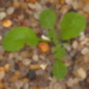

```python
i = 1004
image = X_Preprocessed[i]
label = y['Label'][i]
print(' Seedling Name: ' + label +"\n")
cv2_imshow(image)
```

```
 Seedling Name: Shepherds Purse
```

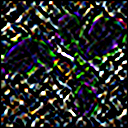

```python
# We can visualize that there are edges.
sobel = cv2.Sobel(image, cv2.CV_64F, 1, 1, ksize=5)
print(' Seedling Name: ' + label +"\n")
cv2_imshow(sobel)
```

### Normalize data

- The pixel values are in the range of 0 to 255 for each of the red, green and blue channels.
- It is good practice to work with normalized data. Because the input values are well understood, we can easily normalize to the range 0 to 1 by dividing each value by the maximum observation which is 255.
- Note, the data is loaded as integers, so we must cast it to floating point values in order to perform the division.

```python
X_Preprocessed = X_Preprocessed.astype('float32') # Conversion to float type from integer type.
X_Preprocessed /= 255.0
```

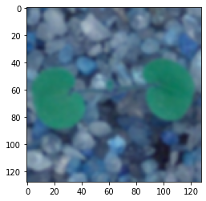

```python
plt.imshow(X_Preprocessed[0])
```

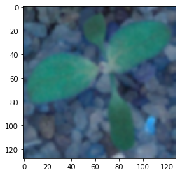

```python
plt.imshow(X_Preprocessed[903])
```

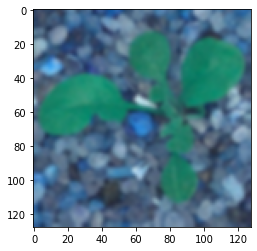

```python
plt.imshow(X_Preprocessed[1004])
```

# **Make data compatible: (10 Marks)**

> a. Convert labels to one-hot-vectors.

> b. Print the label for y[0].

> c. Split the dataset into training, testing, and validation set.

> > (Hint: First split images and labels into training and testing set with test_size = 0.3. Then further split test data into test and validation set with test_size = 0.5)

> d. Check the shape of data, Reshape data into shapes compatible with Keras models if it’s not already. If it’s already in the compatible shape, then comment in the notebook that it’s already in compatible shape.

### One-hot encode the class vector

```python
#Print all the Seedling names
y.Label.unique()
```

```
array(['Small-flowered Cranesbill', 'Fat Hen', 'Shepherds Purse',
       'Common wheat', 'Common Chickweed', 'Charlock', 'Cleavers',
       'Scentless Mayweed', 'Sugar beet', 'Maize', 'Black-grass',
       'Loose Silky-bent'], dtype=object)
```

```python
def seedling_to_numeric(x):
    if x=='Small-flowered Cranesbill':
        return 0
    if x=='Fat Hen':
        return 1
    if x=='Shepherds Purse':
        return 2
    if x=='Common wheat':
        return 3
    if x=='Common Chickweed':
        return 4
    if x=='Charlock':
        return 5
    if x=='Cleavers':
        return 6
    if x=='Scentless Mayweed':
        return 7
    if x=='Sugar beet':
        return 8
    if x=='Maize':
        return 9
    if x=='Black-grass':
        return 10
    if x=='Loose Silky-bent':
        return 11
```

```python
y_numeric = y.copy()
y_numeric['Label'] = y_numeric['Label'].apply(seedling_to_numeric)
```

```python
y_processed = y_numeric.pop("Label")
```

### Print the label for y[0].

```python
y_processed = to_categorical(y_processed, num_classes=12)
print("Shape of y_processed:", y_processed.shape)
print("One value of y_processed:", y_processed[0])
```

```
Shape of y_processed: (4750, 12)
One value of y_processed: [1. 0. 0. 0. 0. 0. 0. 0. 0. 0. 0. 0.]
```

### Split the dataset into training, testing, and validation set.

```python
X_train, X_test, y_train, y_test = train_test_split(X_Preprocessed, y_processed, test_size=0.30, random_state=1)

# Then further split test data into test and validation set with test_size = 0.5
X_validation, X_test, y_validation, y_test = train_test_split(X_test, y_test, test_size=0.50, random_state=1)
```

### Check the shape of data, Reshape data into shapes compatible with Keras models if it’s not already. If it’s already in the compatible shape, then comment in the notebook that it’s already in compatible shape.

```python
print(f'Shape of Training: {X_train.shape}, {y_train.shape}')
print(f'Shape of Validation: {X_validation.shape}, {y_validation.shape}')
print(f'Shapes of Testing: {X_test.shape}, {y_test.shape}')
```

```
Shape of Training: (3325, 128, 128, 3), (3325, 12)
Shape of Validation: (712, 128, 128, 3), (712, 12)
Shapes of Testing: (713, 128, 128, 3), (713, 12)
```

##### Unlike ANN which work on vectors, CNN works on volumes maintaining spatial structures. Hence we don;t have to reshape the data. Its already in the compatible shape.

```python
# Set the batch size, number of epochs.
batch_size = 32
num_classes = 12
epochs = 60
num_predictions = 20
```

# **Building CNN: (15 Marks)**

> a. Define layers.

> b. Set optimizer and loss function. (Use Adam optimizer and categorical crossentropy.)

### Create the Model:

```python
# Create the model
model = Sequential()
model.add(Conv2D(32, (3, 3), padding='same',
                 input_shape=X_train.shape[1:]))
model.add(Activation('relu'))
model.add(Conv2D(32, (3, 3)))
model.add(Activation('relu'))
model.add(MaxPooling2D(pool_size=(2, 2)))
model.add(Dropout(0.25))

model.add(Conv2D(64, (3, 3), padding='same'))
model.add(Activation('relu'))
model.add(Conv2D(64, (3, 3)))
model.add(Activation('relu'))
model.add(MaxPooling2D(pool_size=(2, 2)))
model.add(Dropout(0.25))

model.add(Flatten())
model.add(Dense(512))
model.add(Activation('relu'))
model.add(Dropout(0.5))
model.add(Dense(num_classes))
model.add(Activation('softmax'))
```

```python
# initiate Adam optimizer
opt = keras.optimizers.Adam(learning_rate=0.0001)
```

```python
# Let's train the model using RMSprop
model.compile(loss='categorical_crossentropy',
              optimizer=opt,
              metrics=['accuracy'])
```

```python
# Network structure is summarized which confirms our design was implemented correctly.
model.summary()
```

```
Model: "sequential"
_________________________________________________________________
Layer (type)                 Output Shape              Param #
=================================================================
conv2d (Conv2D)              (None, 128, 128, 32)      896
_________________________________________________________________
activation (Activation)      (None, 128, 128, 32)      0
_________________________________________________________________
conv2d_1 (Conv2D)            (None, 126, 126, 32)      9248
_________________________________________________________________
activation_1 (Activation)    (None, 126, 126, 32)      0
_________________________________________________________________
max_pooling2d (MaxPooling2D) (None, 63, 63, 32)        0
_________________________________________________________________
dropout (Dropout)            (None, 63, 63, 32)        0
_________________________________________________________________
conv2d_2 (Conv2D)            (None, 63, 63, 64)        18496
_________________________________________________________________
activation_2 (Activation)    (None, 63, 63, 64)        0
_________________________________________________________________
conv2d_3 (Conv2D)            (None, 61, 61, 64)        36928
_________________________________________________________________
activation_3 (Activation)    (None, 61, 61, 64)        0
_________________________________________________________________
max_pooling2d_1 (MaxPooling2 (None, 30, 30, 64)        0
_________________________________________________________________
dropout_1 (Dropout)          (None, 30, 30, 64)        0
_________________________________________________________________
flatten (Flatten)            (None, 57600)             0
_________________________________________________________________
dense (Dense)                (None, 512)               29491712
_________________________________________________________________
activation_4 (Activation)    (None, 512)               0
_________________________________________________________________
dropout_2 (Dropout)          (None, 512)               0
_________________________________________________________________
dense_1 (Dense)              (None, 12)                6156
_________________________________________________________________
activation_5 (Activation)    (None, 12)                0
=================================================================
Total params: 29,563,436
Trainable params: 29,563,436
Non-trainable params: 0
_________________________________________________________________
```

```python
#Adding Early stopping callback to the fit function is going to stop the training,
#if the val_loss is not going to change even '0.001' for more than 10 continous epochs
from tensorflow.keras.callbacks import ModelCheckpoint, EarlyStopping

early_stopping = EarlyStopping(monitor='val_loss', min_delta=0.001, patience=10)

#Adding Model Checkpoint callback to the fit function is going to save the weights whenever val_loss achieves a new low value.
#Hence saving the best weights occurred during training

model_checkpoint =  ModelCheckpoint('cnn_checkpoint_{epoch:02d}_loss{val_loss:.4f}.h5',
                                                           monitor='val_loss',
                                                           verbose=1,
                                                           save_best_only=True,
                                                           save_weights_only=True,
                                                           mode='auto',
                                                           period=1)
```

```
WARNING:tensorflow:`period` argument is deprecated. Please use `save_freq` to specify the frequency in number of batches seen.
```

# **Fit and evaluate model and print confusion matrix. (10 Marks)**

```python
model.fit(X_train, y_train,
          batch_size=batch_size,
          epochs=epochs,
          validation_data=(X_validation, y_validation),
          shuffle=True,
          verbose=1,
          callbacks=[early_stopping,model_checkpoint])
```

```
Epoch 00001: val_loss improved from inf to 2.25347, saving model to cnn_checkpoint_01_loss2.2535.h5
Epoch 00002: val_loss improved from 2.25347 to 1.63252, saving model to cnn_checkpoint_02_loss1.6325.h5
Epoch 00003: val_loss improved from 1.63252 to 1.34368, saving model to cnn_checkpoint_03_loss1.3437.h5
Epoch 00004: val_loss improved from 1.34368 to 1.18996, saving model to cnn_checkpoint_04_loss1.1900.h5
Epoch 00005: val_loss improved from 1.18996 to 1.08970, saving model to cnn_checkpoint_05_loss1.0897.h5
Epoch 00006: val_loss improved from 1.08970 to 1.08084, saving model to cnn_checkpoint_06_loss1.0808.h5
Epoch 00007: val_loss improved from 1.08084 to 0.99127, saving model to cnn_checkpoint_07_loss0.9913.h5
Epoch 00008: val_loss improved from 0.99127 to 0.95766, saving model to cnn_checkpoint_08_loss0.9577.h5
Epoch 00009: val_loss did not improve from 0.95766
Epoch 00010: val_loss improved from 0.95766 to 0.93562, saving model to cnn_checkpoint_10_loss0.9356.h5
Epoch 00011: val_loss did not improve from 0.93562
Epoch 00012: val_loss did not improve from 0.93562
Epoch 00013: val_loss improved from 0.93562 to 0.93554, saving model to cnn_checkpoint_13_loss0.9355.h5
Epoch 00014: val_loss did not improve from 0.93554
Epoch 00015: val_loss did not improve from 0.93554
Epoch 00016: val_loss did not improve from 0.93554
Epoch 00017: val_loss did not improve from 0.93554
Epoch 00018: val_loss did not improve from 0.93554
Epoch 00019: val_loss did not improve from 0.93554
Epoch 00020: val_loss did not improve from 0.93554
```

```
<tensorflow.python.keras.callbacks.History at 0x7f03a024def0>
```

### Evaluation

Keras model can be evaluated with evaluate() function

Evaluation results are contained in a list

```python
# Score trained model.
scores = model.evaluate(X_test, y_test, verbose=1)
print('Test loss:', scores[0])
print('Test accuracy:', scores[1])
```

```
Test loss: 0.9433093070983887
Test accuracy: 0.747545599937439
```

### Confusion Matrix

```python
from sklearn import metrics
y_pred = model.predict(X_test)
matrix = metrics.confusion_matrix(y_test.argmax(axis=1), y_pred.argmax(axis=1))
print(matrix)
```

```
[[71  1  3  0  0  2  0  3  1  0  0  0]
 [ 0 50  0  2  6  3  1  0  1  0  0  5]
 [ 2  0 13  0  7  1  1  6  0  0  0  0]
 [ 0  3  0 18  0  0  0  1  0  0  3  9]
 [ 1  1  2  0 84  0  0  3  0  4  0  0]
 [ 0  1  0  0  0 54  1  0  0  0  0  0]
 [ 0  0  0  3  0  9 20  1  0  0  0  0]
 [ 1  1  3  2  2  2  2 65  3  1  0  1]
 [ 2  3  0  1  1  1  1  5 55  1  0  0]
 [ 0  1  1  0  3  2  0  3  1 20  0  1]
 [ 0  2  0  2  0  1  0  1  1  0  7 29]
 [ 1  6  0  0  0  0  0  1  0  0  4 76]]
```

# **Visualize predictions for x_test[2], x_test[3], x_test[33], x_test[36], x_test[59]. (5 Marks)**

```
Predicted label: 11
Softmax Outputs: [2.3770916e-05 2.1096652e-03 1.1831038e-10 3.0034641e-07 2.6043059e-09
 1.8178254e-12 1.2467077e-09 8.6925439e-07 5.4639764e-09 1.0692194e-12
 7.0786984e-03 9.9078661e-01]
```

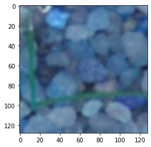

```python
%matplotlib inline
plt.imshow(X_test[2].reshape(128, 128, 3), cmap='gray')
print("Predicted label:", y_pred[2].argmax())
print("Softmax Outputs:", y_pred[2])
```

```
Predicted label: 1
Softmax Outputs: [6.6666253e-04 9.3479776e-01 7.5612252e-04 1.2186446e-02 1.1717209e-03
 3.9588544e-05 3.4603917e-03 2.3116102e-02 5.0931855e-04 3.6239010e-04
 1.4101120e-02 8.8324007e-03]
```

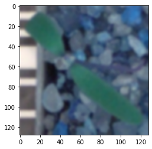

```python
%matplotlib inline
plt.imshow(X_test[3].reshape(128, 128, 3), cmap='gray')
print("Predicted label:", y_pred[3].argmax())
print("Softmax Outputs:", y_pred[3])
```

```
Predicted label: 0
Softmax Outputs: [9.9201787e-01 4.1382329e-05 7.3777679e-03 1.1901986e-08 4.3396788e-08
 3.8523879e-04 1.5843043e-04 9.4205416e-06 9.9446388e-06 2.7081277e-09
 1.1632193e-09 3.7498527e-08]
```

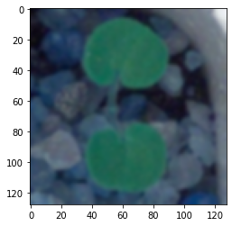

```python
%matplotlib inline
plt.imshow(X_test[33].reshape(128, 128, 3), cmap='gray')
print("Predicted label:", y_pred[33].argmax())
print("Softmax Outputs:", y_pred[33])
```

```
Predicted label: 11
Softmax Outputs: [2.1899532e-06 8.6344121e-04 1.2653021e-07 5.2026729e-03 1.5175681e-05
 3.0769741e-07 6.4487040e-08 1.5933665e-04 2.0216447e-05 3.7859664e-07
 3.1741563e-02 9.6199447e-01]
```

[figure not shown]

```python
%matplotlib inline
plt.imshow(X_test[36].reshape(128, 128, 3), cmap='gray')
print("Predicted label:", y_pred[36].argmax())
print("Softmax Outputs:", y_pred[36])
```

```
Predicted label: 5
Softmax Outputs: [4.3847159e-04 2.9600349e-05 8.7328399e-06 3.9443140e-07 8.2045565e-10
 9.4682831e-01 5.2147914e-02 6.0356961e-05 4.8622797e-04 3.7850697e-08
 3.6002028e-09 3.1025493e-10]
```

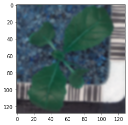

```python
%matplotlib inline
plt.imshow(X_test[59].reshape(128, 128, 3), cmap='gray')
print("Predicted label:", y_pred[59].argmax())
print("Softmax Outputs:", y_pred[59])
```